# Port Phillip Bay seawater temps

The temperatures shown here are sea surface temperatures derived from satellites. They are provided in several places, and what’s here comes from the European Union Copernicus service. This dataset (SST_GLO_SST_L4_NRT_OBSERVATIONS_010_001) has the global oceans divided into grids 0.05° x 0.05°, corresponding roughly to 5km x 5km. It provides “[Foundation](https://www.ghrsst.org/ghrsst-data-services/for-sst-data-users/products/#section5)” temperature, which is the temperature of the uppermost layer of the ocean (typically at a depth of a few centimetres to several meters) that is not affected by diurnal warming or surface cooling due to solar radiation or wind mixing. It represents the baseline or background sea surface temperature from which the diurnal cycle grows each day.

The closest grid cell to Williamstown beach is centred on [Lon. 144.875, Lat. -37.875](https://www.google.com/maps/place/37%C2%B052'30.0%22S+144%C2%B052'30.0%22E/@-37.8749957,144.8338013,13z/data=!4m4!3m3!8m2!3d-37.875!4d144.875?entry=ttu&g_ep=EgoyMDI2MDcyMC4wIKXMDSoASAFQAw%3D%3D). It’s a little bit offshore from the Jawbone, as the global data set excludes grid cells with a substantial proportion of land. As a result, the shallow water right on the coast isn’t included, and that water can get cooler or warmer than further offshore particularly on calm days. Two other snorkelling/diving spots are included; the SE corner of the bay (Blairgowrie, Rye, etc.) is 144.775, -38.375, and just outside Western Port (near Flinders pier) is 145.025, -38.475.

The temperatures are daily measurements, so the graphs are a bit noisy; some other places, such as [baywinds](http://www.baywx.com.au/temps.html), show temperatures averaged over a few days to smooth things out a bit.

## Williamstown

#### Current year, with last year for an immediate comparison

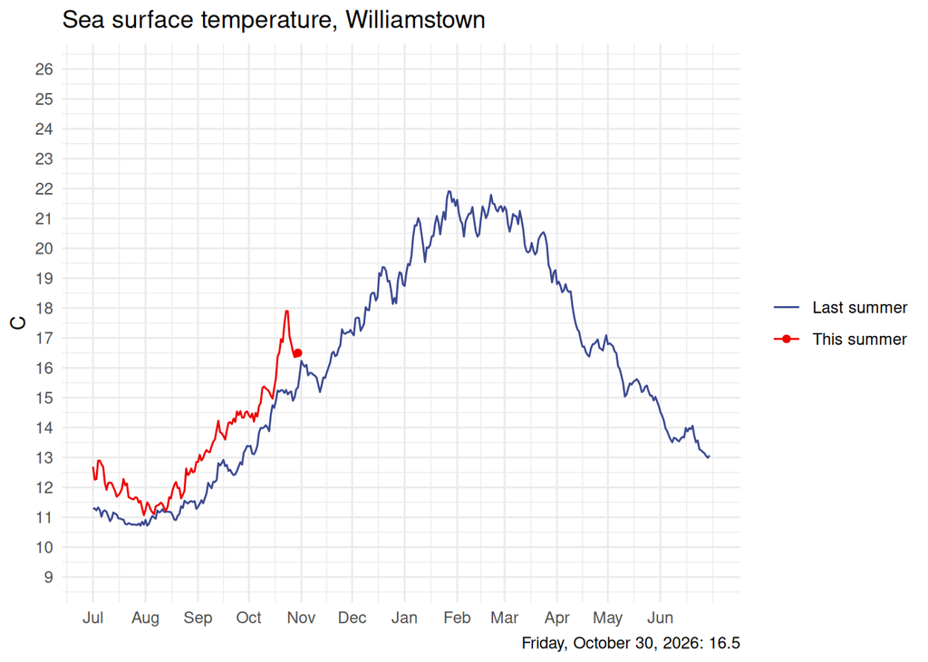

#### Multi-year plots

The first figure shows the current year, other years from the past decade onwards in the background, and the second includes the data since 2002. The third figure shows the current year against 10-year and post-2002 averages. The fourth shows temperature anomalies - how this year’s temperature compares to the average since 2002.

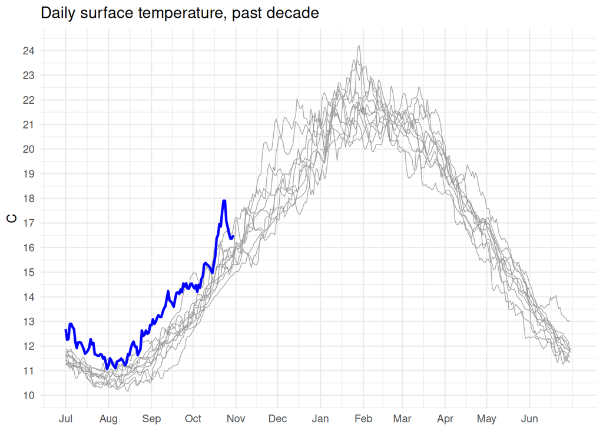

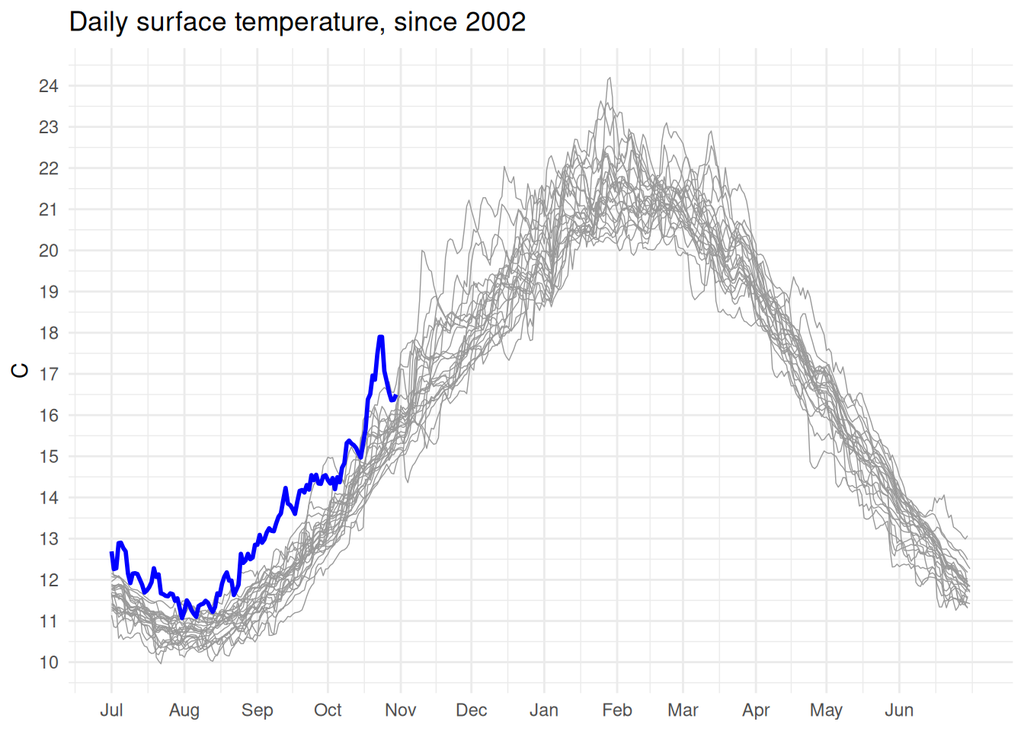

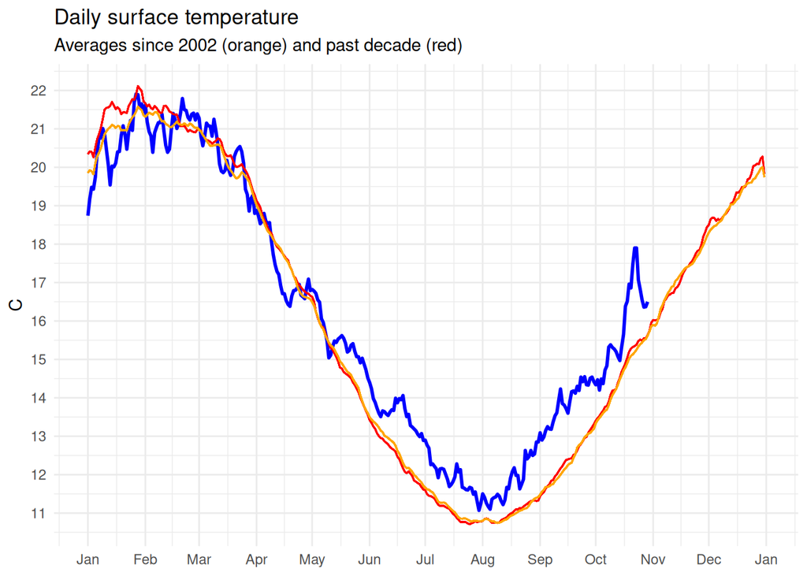

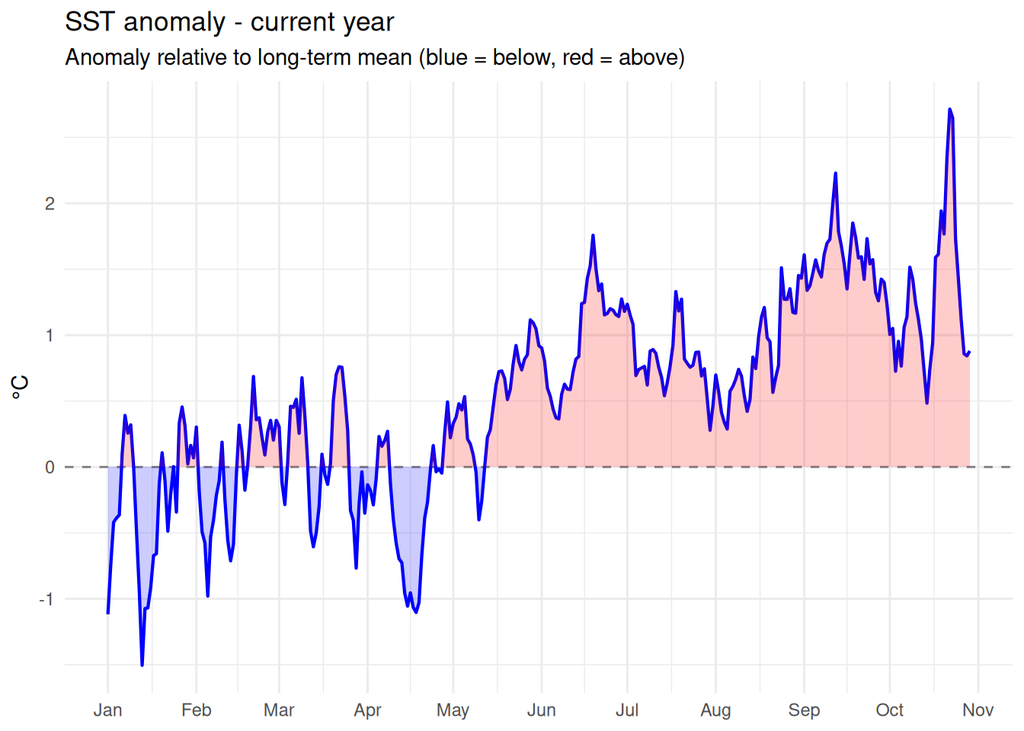

## Three places of interest to divers and snorkellers

Open coast sites, such as Flinders, don’t get as warm or as cold as those near the top of Port Phillip Bay (Williamstown). Places near the entrance of the bay (Blairgowrie, Rye) are intermediate, but closer to open ocean conditions.

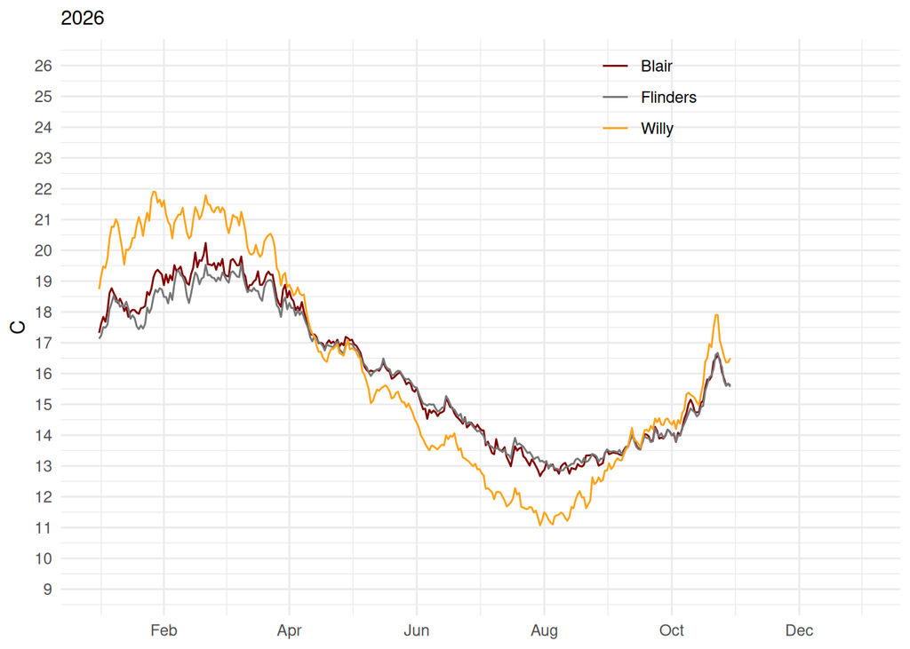

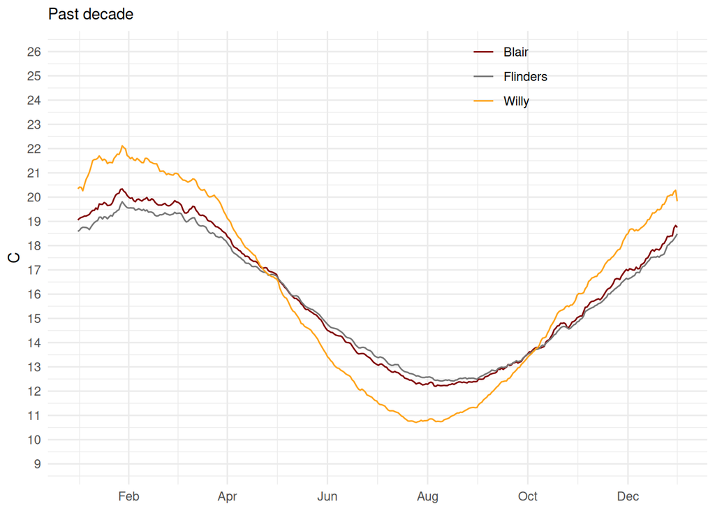

### Temperature contour map

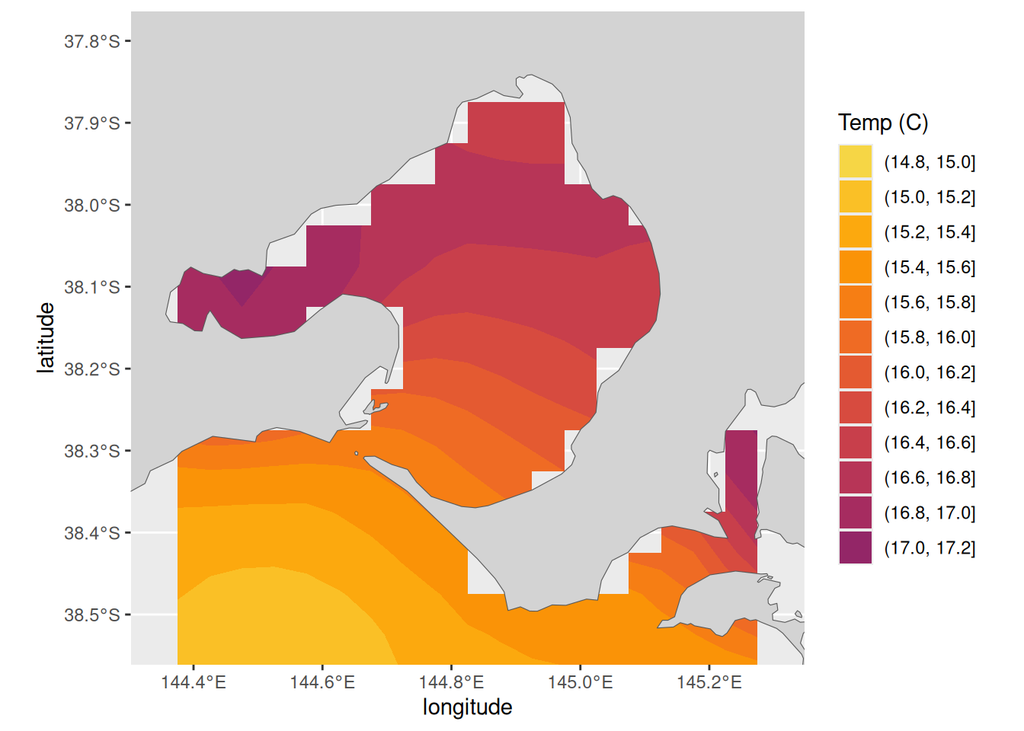